# FinalProject_Report

Daniil Finkel, Omar Boffil, Albert Ferguson

August 2, 2020

#### Team DOT:

- Daniilf2 - Daniil Finkel
- Oboffil2 - Omar Boffil
- Albertf2 - Albert Ferguson

# STAT 420: Final Project

## Predicting UPDRS (Unified Parkinson Disease Rating Scale) from Biomedical Voice Measurements of Individuals with Early Stage Parkinson’s Disease

### Introduction

Our chosen data file contains 22 attributes of 5875 observations. The attributes are:

- subject# - Integer that uniquely identifies each subject
- age - Subject age
- sex - Subject gender ‘0’ - male, ‘1’ - female
- test_time - Time since recruitment into the trial. The integer part is the
- number of days since recruitment.
- motor_UPDRS - Clinician’s motor UPDRS score, linearly interpolated
- total_UPDRS - Clinician’s total UPDRS score, linearly interpolated
- Jitter(%),Jitter(Abs),Jitter:RAP,Jitter:PPQ5,Jitter:DDP
  - Several measures of variation in fundamental frequency
- Shimmer,Shimmer(dB),Shimmer:APQ3,Shimmer:APQ5,Shimmer:APQ11,Shimmer:DDA
  - Several measures of variation in amplitude
- NHR,HNR - Two measures of ratio of noise to tonal components in the voice
- RPDE - A nonlinear dynamical complexity measure
- DFA - Signal fractal scaling exponent
- PPE - A nonlinear measure of fundamental frequency variation

The dataset was created in collaboration by Intel, Oxford and several medical centers to study patient Parkinson’s progression.

The data set is provided by UCI, available here:  
https://archive.ics.uci.edu/ml/datasets/Parkinsons+Telemonitoring

Recently, machine learning has seen significantly more use in healthcare. Through this project and dataset, we seek to get a better understanding of just how and why machine learning pairs so well with medical data.

```r
library(readr)
parkins = read_csv("parkinsons_updrs.csv")
```

The “`subject#`” column is a unique identifier we don’t need for modeling, so we will remove it.

```r
parkins = subset(parkins, select = -c(`subject#`))
```

We will also create an initial 80/20 split of the dataset into a “training” and “testing” portion.

```r
set.seed(42)
park_trn_idx  = sample(nrow(parkins), size = trunc(0.80 * nrow(parkins)))
park_trn_data = parkins[park_trn_idx, ]
park_tst_data = parkins[-park_trn_idx, ]
```

### Methods

#### Helper functions:

We first create a suite of helper functions to more easily evaluate our models.

```r
library(lmtest)

calc_rmse = function(model, tst_data = park_tst_data){
  sqrt(mean((predict(model, tst_data) - tst_data$total_UPDRS) ^ 2))
}

get_bp = function(model) {
  unname(bptest(model)$p.value)
}

get_sw = function(model) {
  unname(shapiro.test(resid(model))$p.value)
}

get_num_params = function(model) {
  length(coef(model))
}

get_loocv_rmse = function(model) {
  sqrt(mean((resid(model) / (1 - hatvalues(model))) ^ 2))
}

get_adj_r2 = function(model) {
  summary(model)$adj.r.squared
}

eval_model = function(model, tst_data = park_tst_data){
  list(b_pagan = get_bp(model),
       shap_wilk = get_sw(model),
       rmse_loocv = get_loocv_rmse(model),
       rmse_trn = sqrt(mean(model$residuals^2)),
       rmse_tst = calc_rmse(model, tst_data),
       adj_r2 = get_adj_r2(model),
       num_p = get_num_params(model))
}

diagnostic_plots = function(model, pcol="grey", lcol="dodgerblue"){
  par(mfrow = c(1,2))
  plot(fitted(model), resid(model), col = pcol,
       xlab = "Fitted", ylab = "Residuals", main = "Fitted vs Residuals")
  abline(h=0, col = lcol)
  qqnorm(resid(model), col = pcol, main = "Normal Q-Q plot")
  qqline(resid(model), col = lcol)
}

non_influential_filter = function(model){
  !(cooks.distance(model) > (4 / length(cooks.distance(model))))
}

plot_pva = function(predicted, actual){
  plot(actual, predicted,
     col = "darkgrey",
     xlab = "Actual",
     ylab = "Predicted",
     main = "Predicted vs Actual")
  grid()
  abline(0, 1, col = "dodgerblue")
}
```

Let’s test the functionality

```r
fit = lm(total_UPDRS ~ . - motor_UPDRS, data = park_trn_data)
#summary(fit)
#eval_model(fit)
#diagnostic_plots(fit)
#sum(!non_influential_filter(fit))
```

#### Correlations

```r
#pairs(total_UPDRS ~ `Jitter(Abs)` + Shimmer + NHR + HNR + DFA + PPE, data = parkins)
#pairs(parkins[, 1:6], lower.panel = NULL,)

library(GGally)
#ggpairs(columns = c('total_UPDRS', 'motor_UPDRS', 'age', 'sex', 'test_time'), data=parkins)
#ggpairs(columns = c('total_UPDRS', 'NHR', 'HNR', 'RPDE', 'DFA', 'PPE'), data=parkins)
ggpairs(columns = c(5, 1, 2, 3, 4), data=parkins)
ggpairs(columns = c(5, 6, 7, 8, 9, 10), data=parkins)
ggpairs(columns = c(5, 11, 12, 13, 14, 15, 16), data=parkins)
ggpairs(columns = c(5, 17, 18, 19, 20, 21), data=parkins)

#ggpairs(columns = c('total_UPDRS', '`Jitter(%)`', '`Jitter(Abs)`', '`Jitter:RAP`', '`Jitter:PPQ5`', '`Jitter:DDP`'), data=parkins)
#ggpairs(columns = c('total_UPDRS', 'Shimmer', '`Shimmer(dB)`', '`Shimmer:APQ3`', '`Shimmer:APQ5`', '`Shimmer:APQ11`', '`Shimmer:DDA`'), data=parkins)
```

[output not shown]

#### Variance Inflation Factor

```r
vifs = round(car::vif(fit), 3)
#vifs[vifs > 5]
vifs[vifs > 10]
```

```
##     `Jitter(%)`    `Jitter:RAP`   `Jitter:PPQ5`    `Jitter:DDP`
##          88.442     1377890.086          30.812     1377939.182
##         Shimmer   `Shimmer(dB)`  `Shimmer:APQ3`  `Shimmer:APQ5`
##         174.703          78.812    24142016.881          49.172
## `Shimmer:APQ11`   `Shimmer:DDA`
##          14.631    24142345.797
```

```r
non_inf_fit = lm(total_UPDRS ~ . - motor_UPDRS, data = park_trn_data, subset = non_influential_filter(fit))
n = length(resid(non_inf_fit))
back_aic = step(non_inf_fit, direction = "backward", trace = 0, k = log(n))
eval_model(non_inf_fit)
```

```
## $b_pagan
## [1] 1.778318e-32
##
## $shap_wilk
## [1] 1.178391e-23
##
## $rmse_loocv
## [1] 9.298805
##
## $rmse_trn
## [1] 9.257055
##
## $rmse_tst
## [1] 9.647859
##
## $adj_r2
## [1] 0.2074798
##
## $num_p
## [1] 20
```

```r
eval_model(back_aic)
```

```
## $b_pagan
## [1] 8.760107e-33
##
## $shap_wilk
## [1] 9.381948e-24
##
## $rmse_loocv
## [1] 9.309079
##
## $rmse_trn
## [1] 9.27911
##
## $rmse_tst
## [1] 9.65792
##
## $adj_r2
## [1] 0.2049209
##
## $num_p
## [1] 13
```

```r
summary(back_aic)
```

```
##
## Call:
## lm(formula = total_UPDRS ~ age + sex + test_time + `Jitter(Abs)` +
##     `Jitter:DDP` + `Shimmer:APQ3` + `Shimmer:APQ11` + NHR + HNR +
##     RPDE + DFA + PPE, data = park_trn_data, subset = non_influential_filter(fit))
##
## Residuals:
##     Min      1Q  Median      3Q     Max
## -26.212  -7.157  -1.486   7.310  26.913
##
## Coefficients:
##                   Estimate Std. Error t value Pr(>|t|)
## (Intercept)      4.357e+01  3.479e+00  12.522  < 2e-16 ***
## age              2.798e-01  1.620e-02  17.271  < 2e-16 ***
## sex             -3.017e+00  3.507e-01  -8.604  < 2e-16 ***
## test_time        2.191e-02  2.594e-03   8.447  < 2e-16 ***
## `Jitter(Abs)`   -1.028e+05  1.197e+04  -8.589  < 2e-16 ***
## `Jitter:DDP`     4.238e+02  4.950e+01   8.562  < 2e-16 ***
## `Shimmer:APQ3`  -2.291e+02  2.933e+01  -7.811 7.01e-15 ***
## `Shimmer:APQ11`  9.379e+01  1.972e+01   4.756 2.04e-06 ***
## NHR             -3.764e+01  6.056e+00  -6.215 5.59e-10 ***
## HNR             -6.903e-01  7.471e-02  -9.240  < 2e-16 ***
## RPDE             9.287e+00  1.991e+00   4.664 3.19e-06 ***
## DFA             -3.775e+01  2.519e+00 -14.984  < 2e-16 ***
## PPE              1.782e+01  3.140e+00   5.675 1.47e-08 ***
## ---
## Signif. codes:  0 '***' 0.001 '**' 0.01 '*' 0.05 '.' 0.1 ' ' 1
##
## Residual standard error: 9.292 on 4562 degrees of freedom
## Multiple R-squared:  0.207,  Adjusted R-squared:  0.2049
## F-statistic: 99.24 on 12 and 4562 DF,  p-value: < 2.2e-16
```

```r
predicted = predict(back_aic, park_trn_data)
calc_rmse(back_aic)
```

```
## [1] 9.65792
```

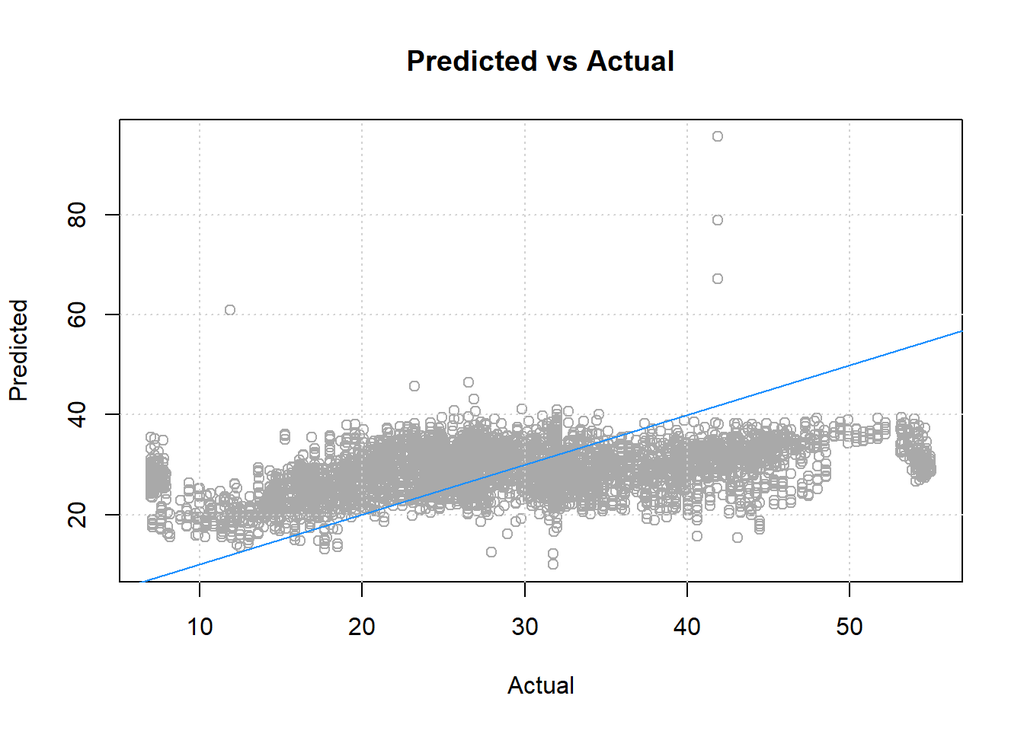

```r
plot_pva(predicted, park_trn_data$total_UPDRS)
```

```r
predicted = predict(back_aic, park_tst_data)
calc_rmse(back_aic)
```

```
## [1] 9.65792
```

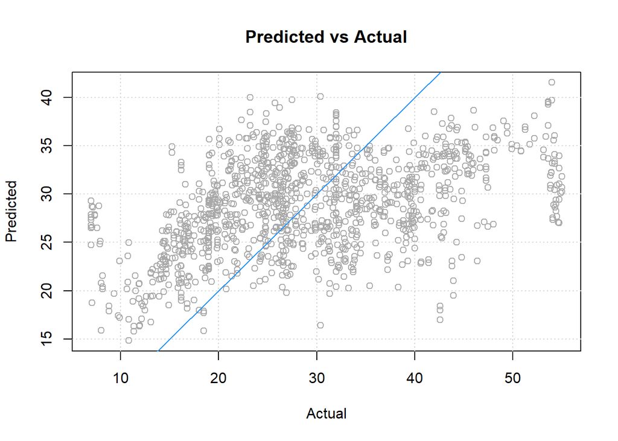

```r
plot_pva(predicted, park_tst_data$total_UPDRS)
```

Let’s try a simple model

```r
simple = lm(total_UPDRS ~ `Jitter(Abs)` + Shimmer + NHR + HNR + DFA + PPE, data = park_trn_data)
eval_model(simple)
```

```
## $b_pagan
## [1] 3.550953e-11
##
## $shap_wilk
## [1] 9.106385e-23
##
## $rmse_loocv
## [1] 10.22155
##
## $rmse_trn
## [1] 10.20807
##
## $rmse_tst
## [1] 10.2321
##
## $adj_r2
## [1] 0.08756807
##
## $num_p
## [1] 7
```

```r
predicted = predict(simple, park_tst_data)
calc_rmse(simple)
```

```
## [1] 10.2321
```

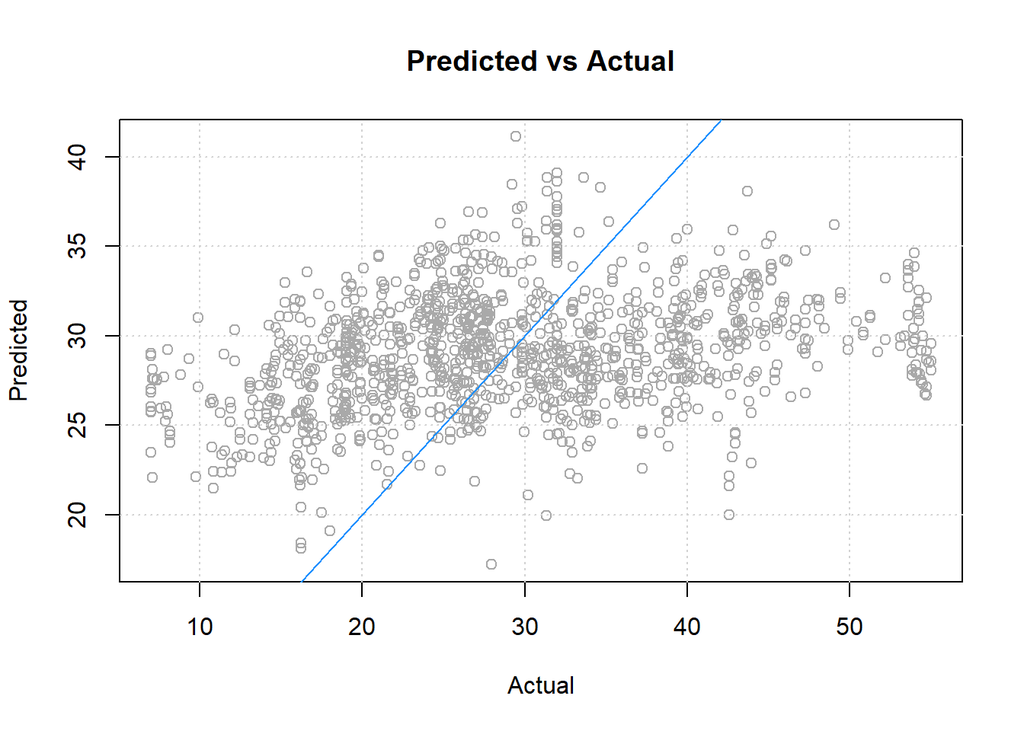

```r
plot_pva(predicted, park_tst_data$total_UPDRS)
```

Let’s try an interaction model

```r
inter = lm(total_UPDRS ~ (. - motor_UPDRS - `Jitter:RAP` - `Shimmer:APQ3` - test_time - sex - NHR)^2, data = park_trn_data)
eval_model(inter)
plot_pva(predict(inter, park_tst_data), park_tst_data$total_UPDRS)

sum(non_influential_filter(inter))
non_inf_fit = lm(total_UPDRS ~ (. - motor_UPDRS - `Jitter:RAP` - `Shimmer:APQ3` - test_time - sex - NHR)^2, data = park_trn_data, subset = non_influential_filter(inter))
eval_model(non_inf_fit)
plot_pva(predict(non_inf_fit, park_tst_data), park_tst_data$total_UPDRS)

n = length(resid(non_inf_fit))
back_aic = step(non_inf_fit, direction = "backward", trace = 0, k = log(n))
eval_model(back_aic)
```

[output not shown]